# Lab 05: Colors with Animal Sounds

### 8.5.4 Palettes from the Queen Bee

To use [Beyonce palettes](https://github.com/dill/beyonce), you’ll need to install the `beyonce` package from GitHub using `devtools::install_github()`. This chunk of code tells you how:

```r
install.packages("devtools")
devtools::install_github("dill/beyonce")
library(beyonce)
```

Note that a number of students had installation problems with this package! Move on if you do.

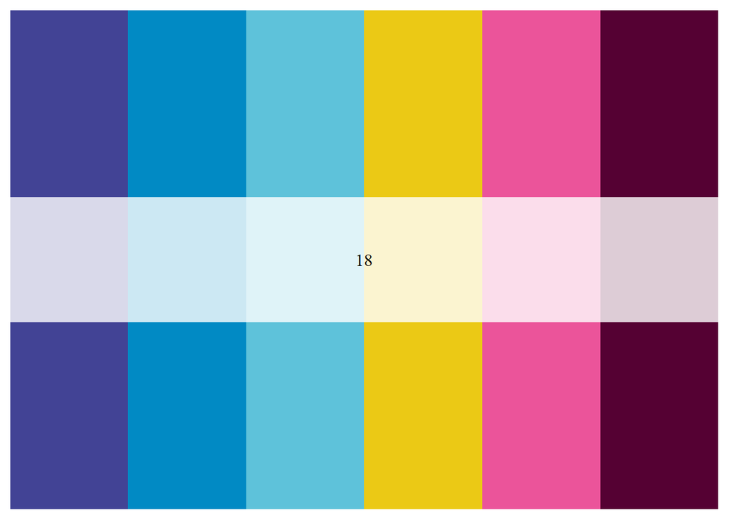

```r
beyonce_palette(18)
```

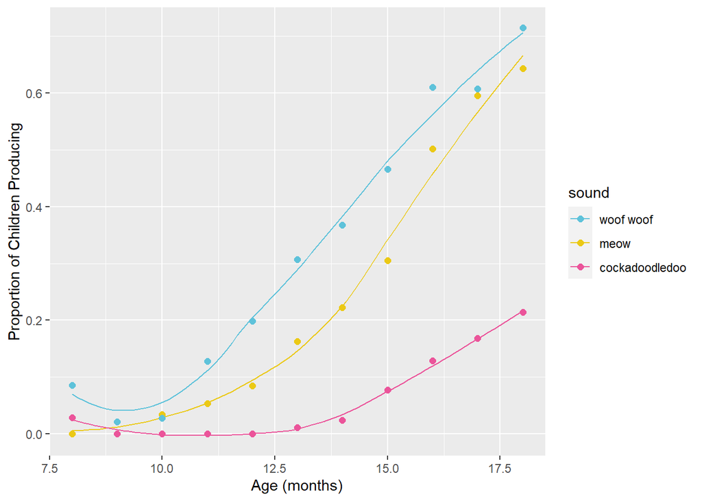

```r
sound_traj +
  scale_color_manual(values = beyonce_palette(18)[3:5])
```

Here we’ll only use the first, fourth, and fifth colors in the palette.

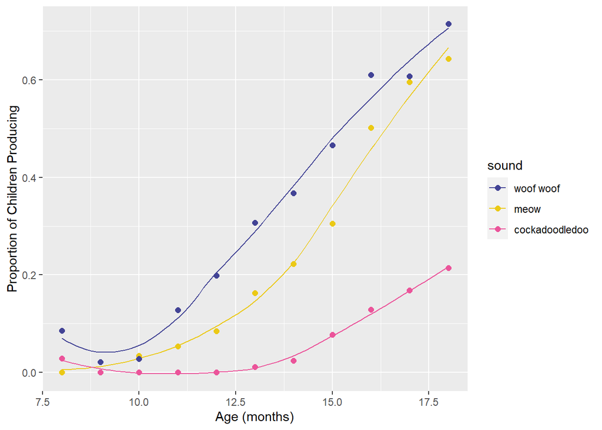

```r
sound_traj +
  scale_color_manual(values = beyonce_palette(18)[c(1, 4, 5)])
```

### 8.5.5 Viridis palettes

To use, you’ll need to install the `viridis` package from CRAN. This chunk of code tells you how:

```r
install.packages("viridis")
library(viridis)
```

Read more here in the [viridis vignette](https://cran.r-project.org/web/packages/viridis/vignettes/intro-to-viridis.html). The default argument for `discrete` is FALSE, so to use the discrete palettes you need to set `discrete = TRUE`. There are four colormap options available:

- “magma” (or “A”),
- “inferno” (or “B”),
- “plasma” (or “C”),
- “viridis” (or “D”, the default option).

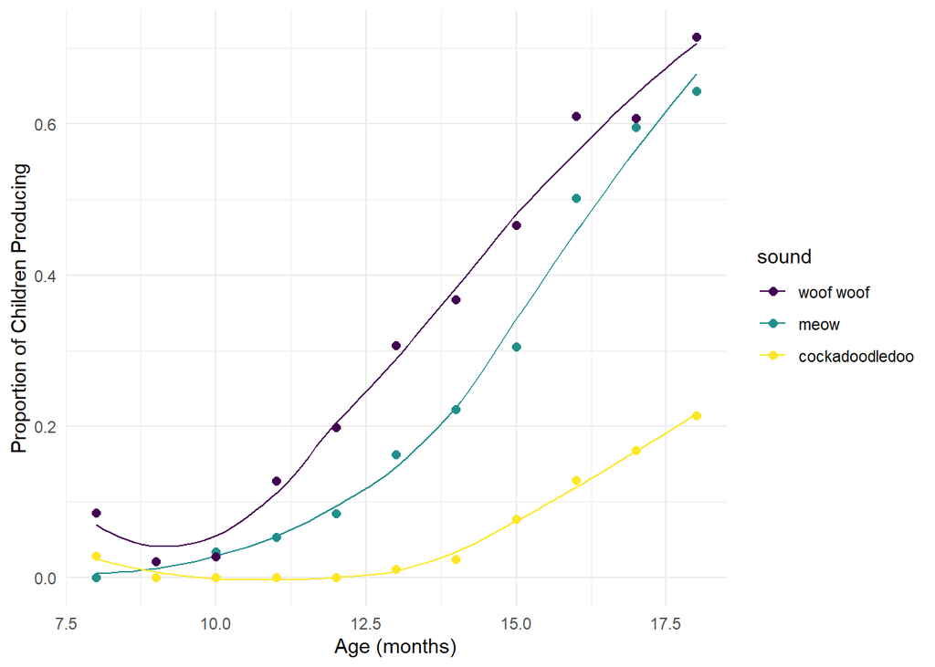

```r
sound_traj +
  scale_color_viridis(discrete = TRUE) +
  theme_minimal()
```

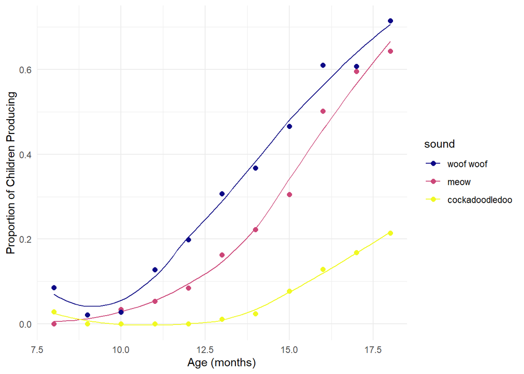

```r
sound_traj +
  scale_color_viridis(discrete = TRUE, option = "plasma") +
  theme_minimal()
```

**Challenge #9:**

Use the `viridis` package to color the points by and the lines by `sound`; make the outline of the points “midnightblue”. Pick any colormap option, and play with `theme_bw` or `theme_minimal` to see what you like.

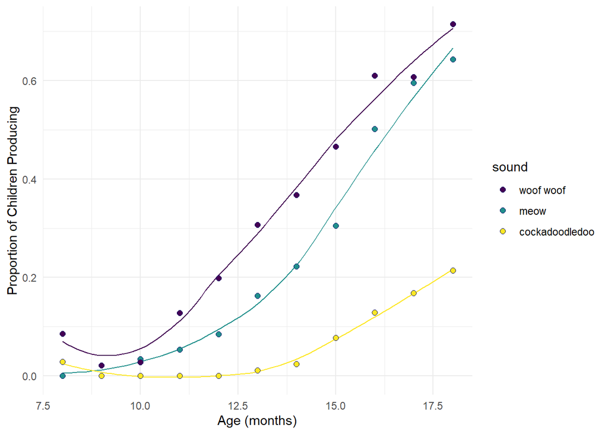

```r
ggplot(sounds, aes(x = age,
                   y = prop_produce,
                   fill = fct_reorder2(sound, age, prop_produce))) +
  geom_smooth(aes(color = fct_reorder2(sound, age, prop_produce)),
              se = FALSE, lwd = .5, show.legend = FALSE) +
  geom_point(size = 2, shape = 21, colour = "midnightblue") +
  labs(x = "Age (months)",
       y = "Proportion of Children Producing",
       fill = "sound") +
  scale_fill_viridis(discrete = TRUE) +
  scale_color_viridis(discrete = TRUE) +
  theme_minimal()
```

## 8.6 Greyscale for discrete

Use `scale_color_grey` or `scale_fill_grey`, or sometimes both depending on your geoms and the aesthetics they understand.

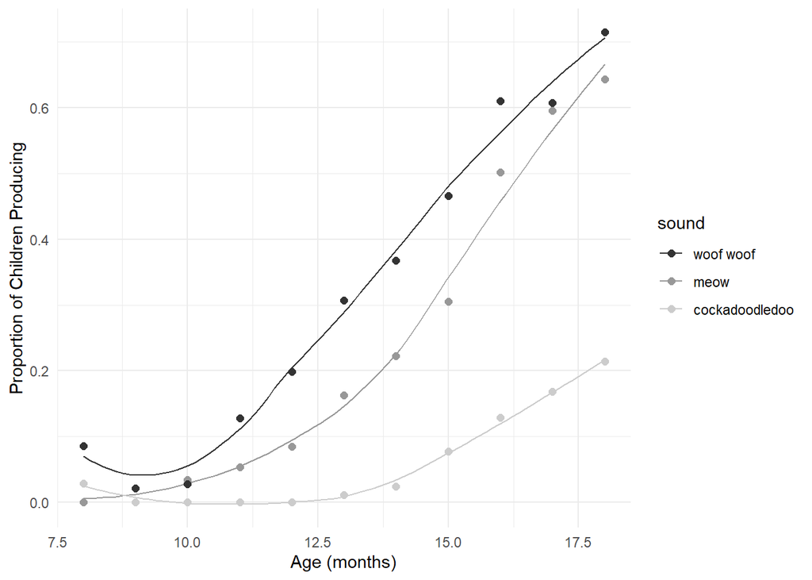

```r
sound_traj +
  scale_color_grey() +
  theme_minimal()
```

Set start and end

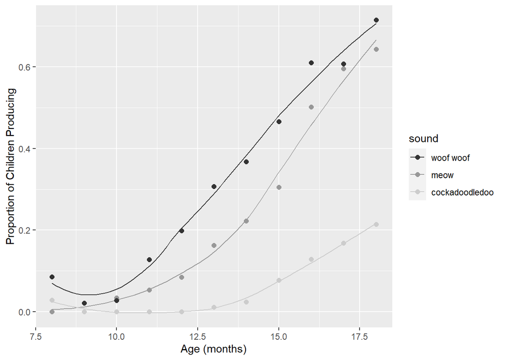

```r
sound_traj +
  scale_color_grey(start = 0.2, end = .8)
```

Make the same plot but make points outlined in black

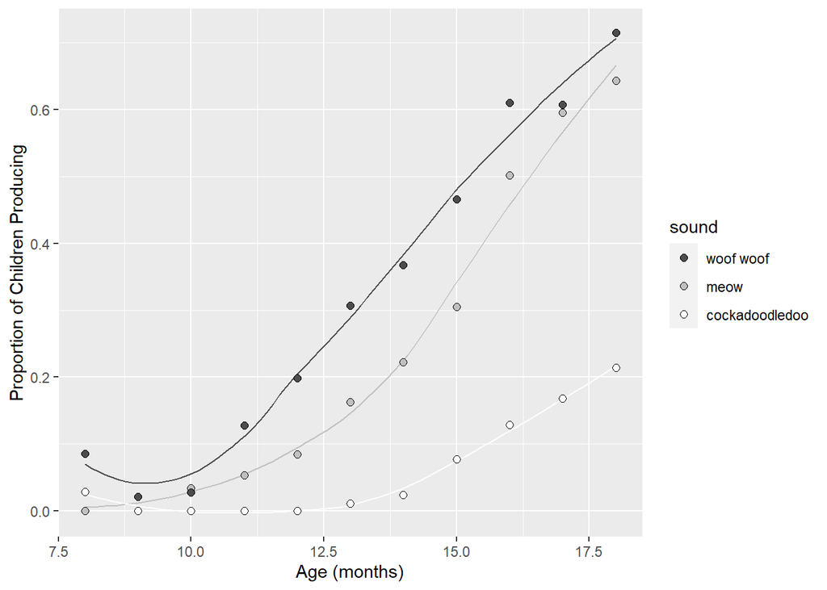

```r
ggplot(sounds, aes(x = age,
                   y = prop_produce,
                   fill = fct_reorder2(sound, age, prop_produce))) +
  geom_smooth(aes(color = fct_reorder2(sound, age, prop_produce)),
              se = FALSE, lwd = .5, show.legend = FALSE) +
  geom_point(size = 2, shape = 21) +
  labs(x = "Age (months)",
       y = "Proportion of Children Producing",
       fill = "sound") +
  scale_fill_grey(start = 0.3, end = 1) +
  scale_color_grey(start = 0.3, end = 1)
```

Suggest redundancy in greyscale- try changing line type instead of line (or in addition to) line color.

Change line type by `sound`, set color to black.

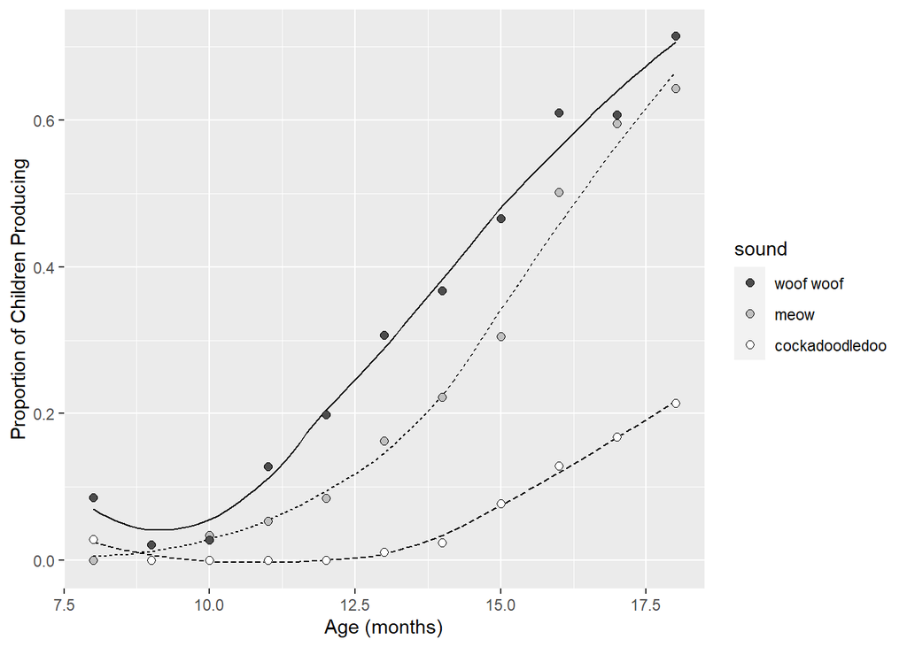

```r
ggplot(sounds, aes(x = age,
                   y = prop_produce,
                   fill = fct_reorder2(sound, age, prop_produce))) +
  geom_smooth(aes(lty = fct_reorder2(sound, age, prop_produce)), color = "black",
              se = FALSE, lwd = .5, show.legend = FALSE) +
  geom_point(size = 2, shape = 21) +
  labs(x = "Age (months)",
       y = "Proportion of Children Producing",
       fill = "sound") +
  scale_fill_grey(start = 0.3, end = 1)
```

Change both!

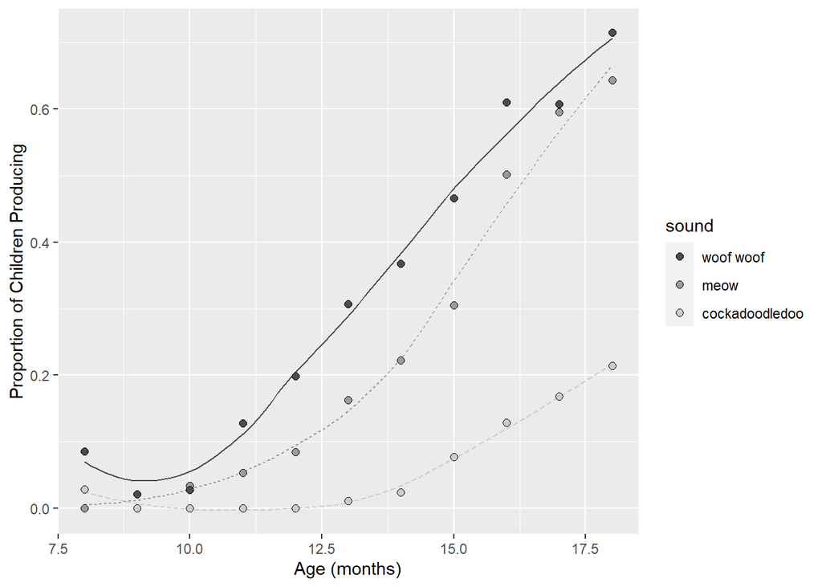

```r
ggplot(sounds, aes(x = age,
                   y = prop_produce,
                   fill = fct_reorder2(sound, age, prop_produce))) +
  geom_smooth(aes(color = fct_reorder2(sound, age, prop_produce),
                  lty = fct_reorder2(sound, age, prop_produce)),
              se = FALSE, lwd = .5, show.legend = FALSE) +
  geom_point(size = 2, shape = 21) +
  labs(x = "Age (months)",
       y = "Proportion of Children Producing",
       fill = "sound") +
  scale_fill_grey(start = 0.3, end = .8) +
  scale_color_grey(start = 0.3, end = .8)
```

## 8.7 Colorblind-friendly palettes

The [`colorblindr` package](https://github.com/clauswilke/colorblindr) can be used to “simulate colorblindness in production-ready R figures.” To use this package, you’ll need to first install the `cowplot` package from GitHub using `devtools::install_github()`. You’ll also need to install the `colorspace` package from CRAN. Finally, you can then use `devtools::install_github()` again to install the `colorblindr` package. This code chunk shows you how to do all 3 installs to use the `colorblindr` package:

```r
devtools::install_github("wilkelab/cowplot")
install.packages("colorspace", repos = "http://R-Forge.R-project.org")
devtools::install_github("clauswilke/colorblindr")
```

To use:

```r
# save a ggplot object
my_sound_traj <- sound_traj +
  scale_color_manual(values = beyonce_palette(18)[c(1, 4, 5)])
```

View that figure after color-vision-deficiency simulation:

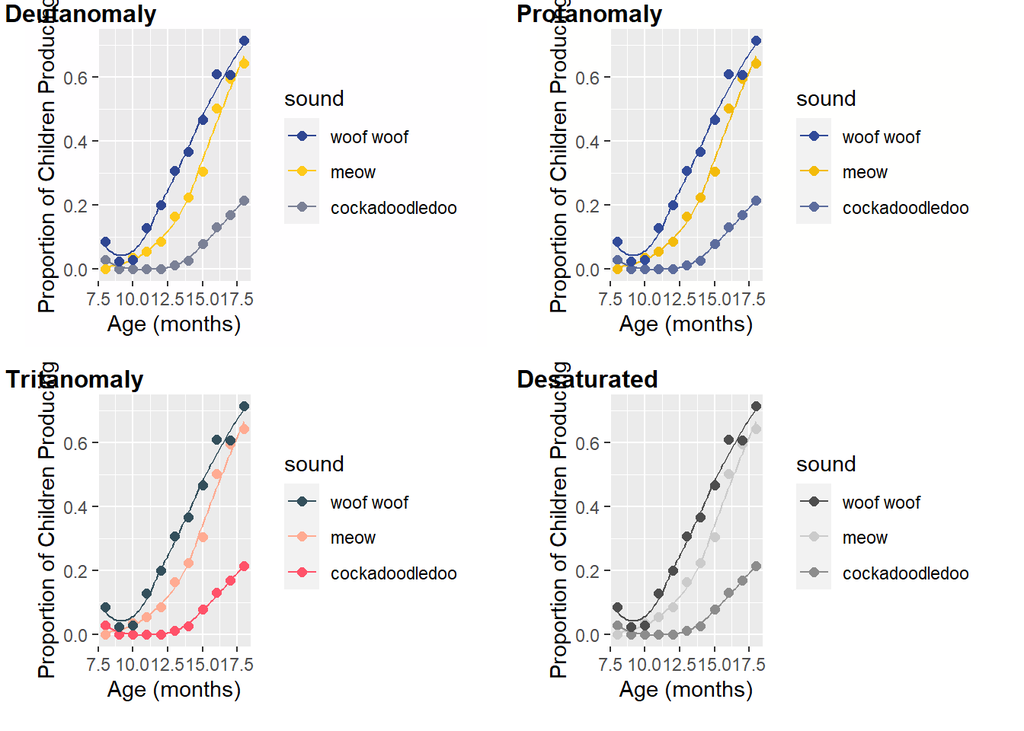

```r
library(colorblindr)
cvd_grid(my_sound_traj)
```

You can also use the colorblind-friendly palette in this package using `scale_color_OkabeIto` and `scale_fill_OkabeIto`:

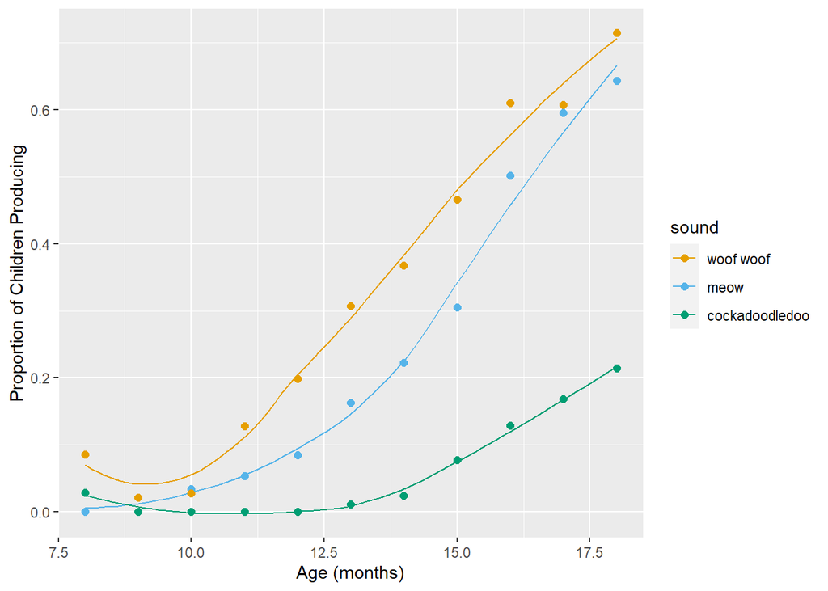

```r
cb_sound_traj <- sound_traj +
  scale_color_OkabeIto()

cb_sound_traj
```

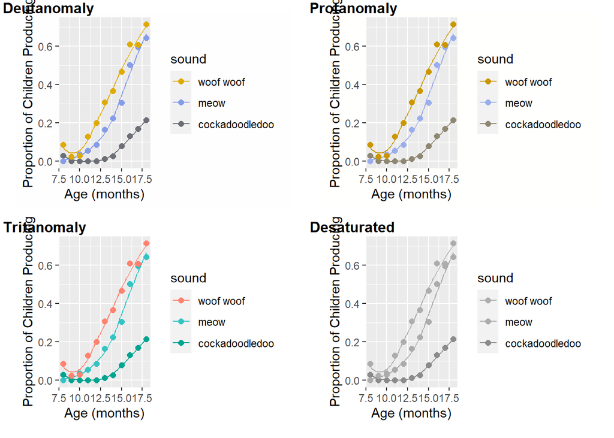

```r
cvd_grid(cb_sound_traj)
```

You can still use this colorblind-friendly palette without the `colorblindr` package though. [Here](http://jfly.iam.u-tokyo.ac.jp/color/) are the colors!

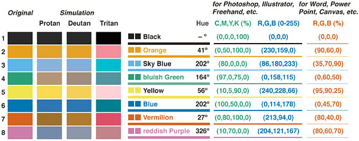

The Cookbook for R provided the matching hex colors too to make life easier:

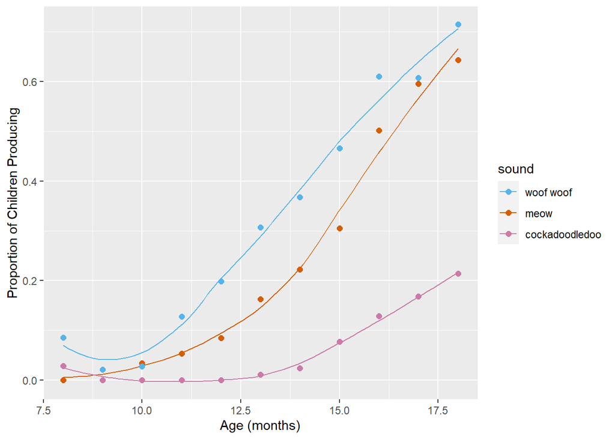

```r
cbbPalette <- c("#000000", "#E69F00", "#56B4E9", "#009E73", "#F0E442", "#0072B2", "#D55E00", "#CC79A7")

# To use for line and point colors, add
sound_traj +
  scale_colour_manual(values = cbbPalette[c(3, 7, 8)])
```

## 8.8 Repel labels

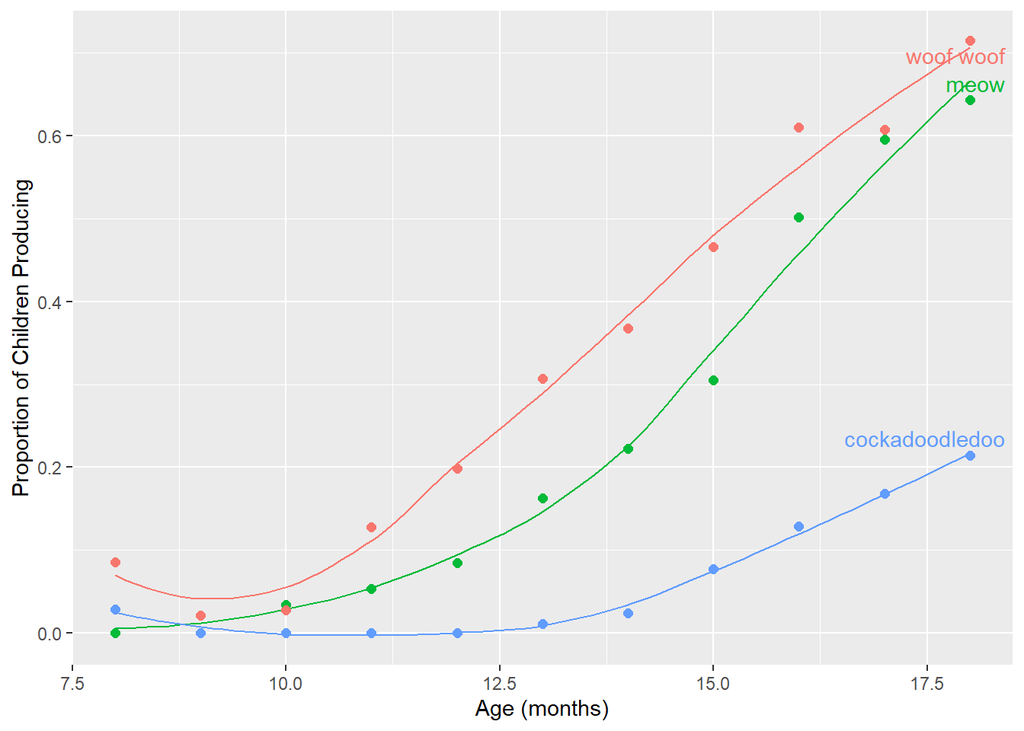

```r
library(ggrepel)

sounds <- sounds %>%
  mutate(label = case_when(
    age == max(age) ~ sound))

ggplot(sounds, aes(x = age,
                   y = prop_produce,
                   color = fct_reorder2(sound, age, prop_produce))) +
  geom_smooth(se = FALSE, lwd = .5) +
  geom_point(size = 2) +
  labs(x = "Age (months)",
       y = "Proportion of Children Producing") +
  geom_text_repel(aes(label = label),
                  nudge_x = 1,
                  direction = "y",
                  na.rm = TRUE) +
  guides(color = "none")
```

# 9 Continuous colors

*N.B. All of the example plots below are great examples of how **not** to use continuous colors. I’m showing these so you can see how to work with continuous color palettes, and to make this topic flow easier for you I’m sticking with original dataset.*

## 9.1 Default continuous palette

Let’s map color to a continuous variable. For this, we are returning to `geom_line` instead of `geom_smooth`, because the latter doesn’t respond to continuous color palettes.

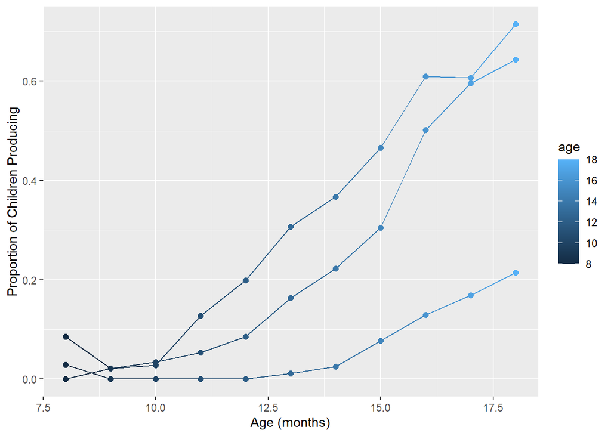

```r
sound_by_age <- ggplot(sounds, aes(x = age,
                                   y = prop_produce,
                                   color = age)) +
  geom_line(aes(group = sound), lwd = .5) +
  geom_point(size = 2) +
  labs(x = "Age (months)",
       y = "Proportion of Children Producing")
sound_by_age
```

## 9.2 Color choice with continuous variables

With discrete colors, we used either `scale_color_manual` or `scale_fill_manual` (and sometimes both were needed!). For continuous colors, we use either `scale_color_gradient` or `scale_fill_gradient`.

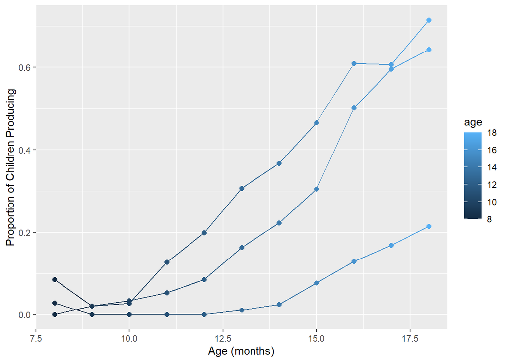

```r
sound_by_age +
  scale_color_gradient()
```

You can reverse the gradient scale…

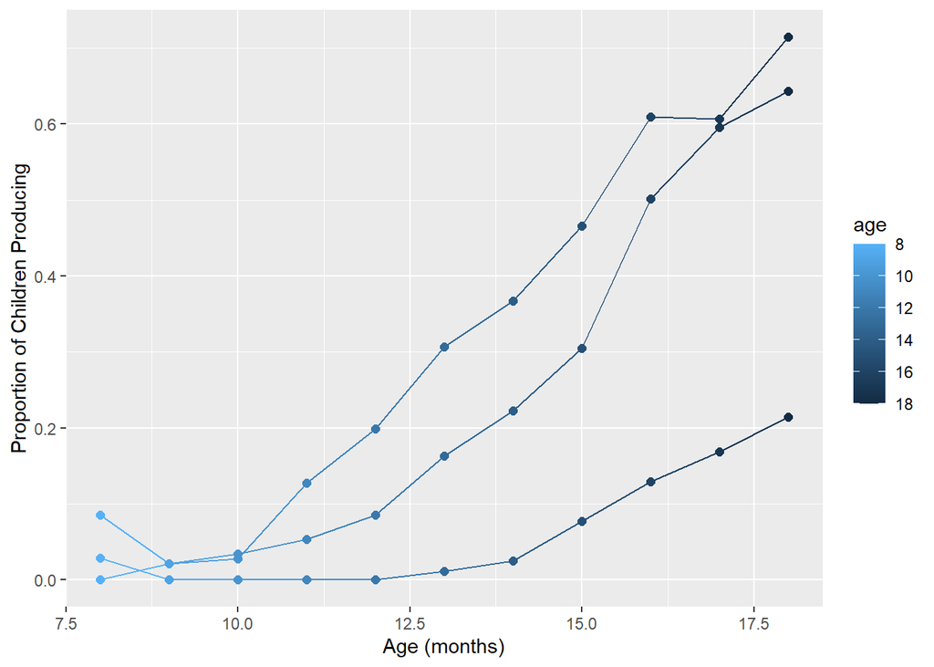

```r
sound_by_age +
  scale_color_gradient(trans = "reverse")
```

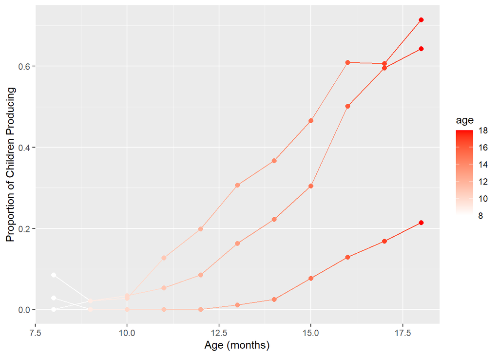

```r
sound_by_age +
  scale_color_gradient(low = "white", high = "red")
```

We can make this same plot using a custom greyscale gradient.

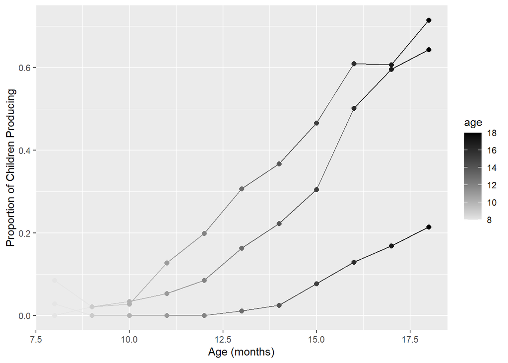

```r
sound_by_age +
  scale_color_gradient(low = "grey90", high = "black")
```

So `scale_color_gradient` gives you a sequential gradient, but you may want a diverging color scheme instead. For that, you can use `scale_color_gradient2`

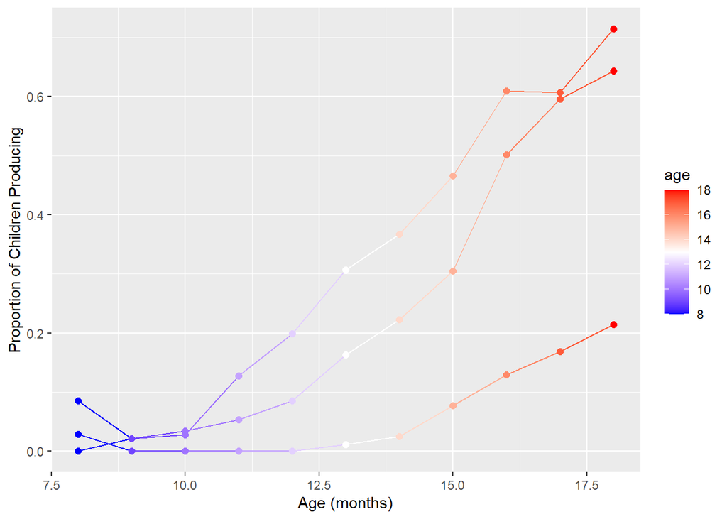

```r
# Diverging color scheme
med_age <- sounds %>%
  summarize(mos = median(age)) %>%
  pull()
sound_by_age +
  scale_color_gradient2(midpoint = med_age,
                      low="blue", mid="white", high="red" )
```

## 9.3 Built-in continuous palettes

### 9.3.1 Use `RColorBrewer`

Again, to use you need to install and load the `RColorBrewer` palette.

```r
library(RColorBrewer)
```

Then use `scale_color_gradientn`.

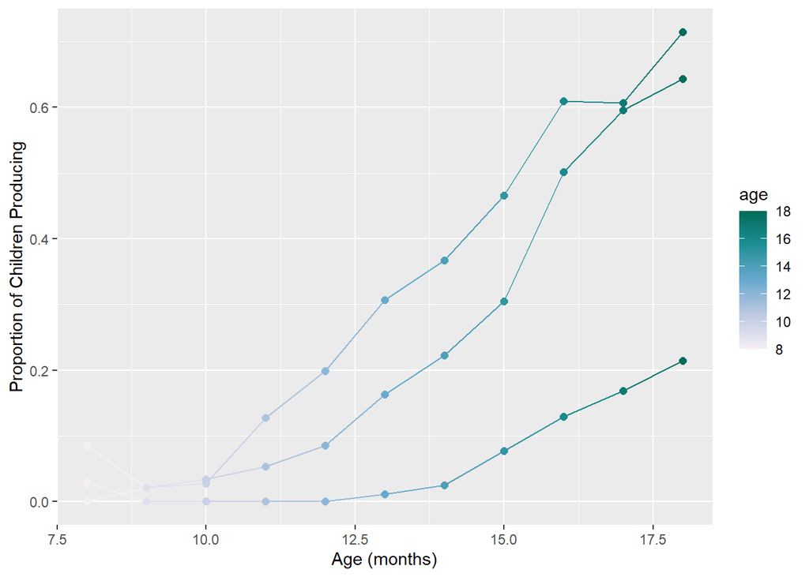

```r
sound_by_age +
  scale_color_gradientn(colours = brewer.pal(n=5, name="PuBuGn"))
```

Reverse the colors…

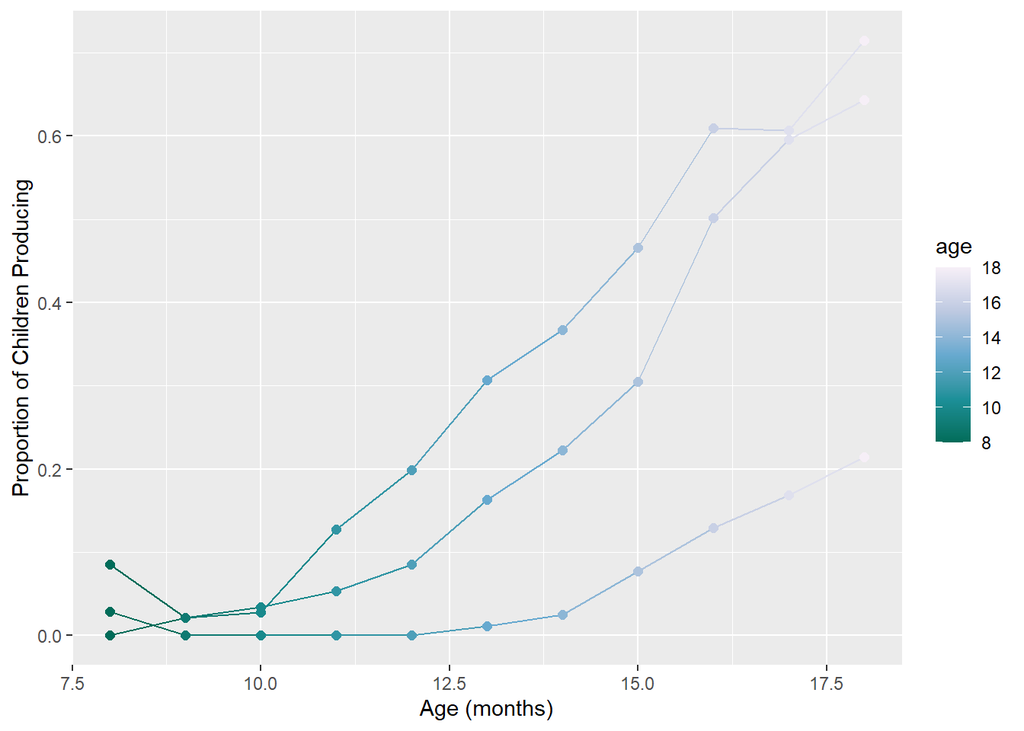

```r
sound_by_age +
  scale_color_gradientn(colours = rev(brewer.pal(n=5, name="PuBuGn")))
```

### 9.3.2 Viridis

Read more here in the [viridis vignette](https://cran.r-project.org/web/packages/viridis/vignettes/intro-to-viridis.html)

```r
library(viridis)
```

The default is the `viridis` palette within the `viridis` package!

Note! For discrete == FALSE (the default) all other arguments are as to `scale_fill_gradientn` or `scale_color_gradientn`.

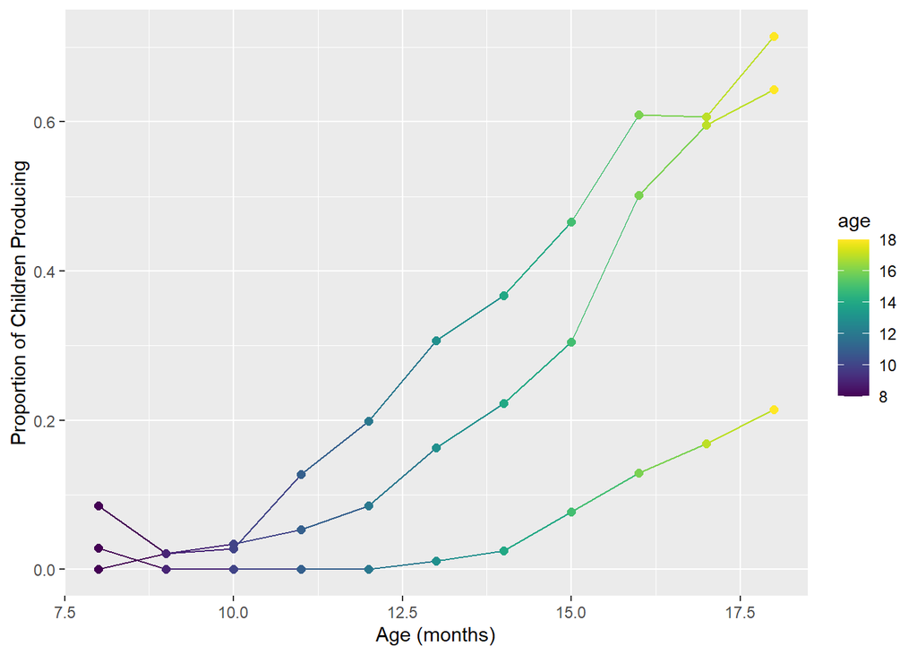

```r
sound_by_age +
  scale_color_viridis()
```

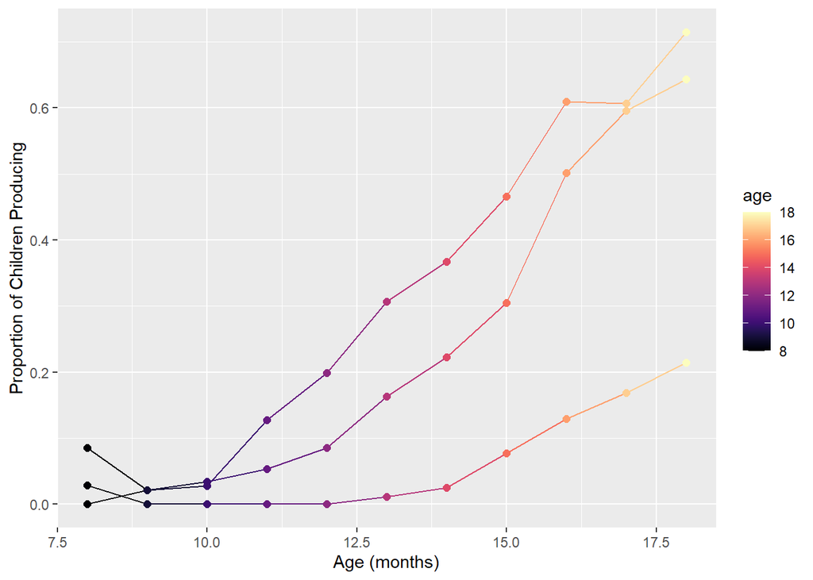

```r
sound_by_age +
  scale_color_viridis(option = "magma")
```

Read the help function for `?scale_color_viridis`. We’ll use the “inferno” palette *in reverse*.

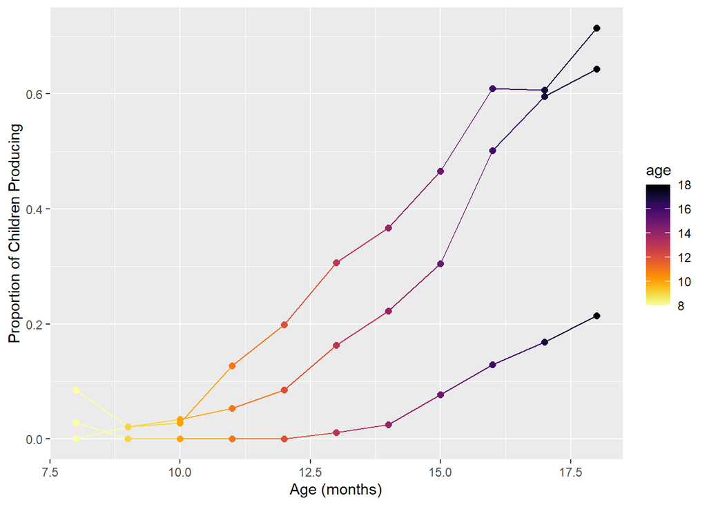

```r
sound_by_age +
  scale_color_viridis(option = "inferno", begin = 1, end = 0)
```

# 10 Final challenge (#10)

**Challenge #10:**

Using new data, make three new plots. Use any `geom` that makes sense. The plots should:

- Have x- and y-axes that are each quantitative variables.
- Apply a non-default color palette, either coloring by a qualitative variable (discrete colors) or a quantitative variable (continuous colors). This list of [R color palettes](https://github.com/EmilHvitfeldt/r-color-palettes) has even more ideas than we could cover in class.
1. In the first plot, you must **wield color carefully and effectively**. The addition of the color/fill aesthetics must be done in a way that the interpretation of the plot improves. Also, you must show how your colors fare for colorblind viewers. Include 2-3 sentences about why you made the plot that you did. What questions does your plot answers (or perhaps what questions does your plot raise)?
2. In the second plot, you must **make a greyscale version of your first plot!** And again, it must look good and make sense.
3. In the third plot, you must **use color badly**. Make a plot where the colors are either redundant, confusing, or just generally non-sensical. Explain why this last visualization fails.

Some data ideas:

- MacArthur-Bates Communicative Development Inventory (MB-CDI), a family of parent-report questionnaires measuring children’s vocabulary understanding and production
  - [R package `wordbankr`](https://cran.r-project.org/web/packages/wordbankr/index.html)
  - See my code here
- POTUS Executive Orders
  - [Data](https://www.federalregister.gov/executive-orders)
  - Follow Bob Rudis’ code-through [here](https://rud.is/b/2018/04/18/examining-potus-executive-orders/)
- National Electronic Injury Surveillance System (NEISS)
  - [R package `neiss`](https://github.com/hadley/neiss)
  - Follow Julia Silge’s code-through [here](https://juliasilge.com/blog/your-floor/)
- Flights
  - [R package `pnwflights14`](https://github.com/ismayc/pnwflights14)
  - [R package `nycflights13`](https://github.com/hadley/nycflights13)
- Building Permits
  - See code [here](https://github.com/hadley/building-permits)
  - Watch YouTube code-through [here](https://www.youtube.com/watch?v=go5Au01Jrvs)
- Cocktail Balance
  - [Data](https://github.com/karnesky/cocktail-balance)
- NASA Weather
  - [Data](https://github.com/hadley/nasaweather)
- Social Security Administration Baby Names
  - [R package `babynames`](https://cran.r-project.org/web/packages/babynames/index.html)
  - Follow Julia Silge *‘My Baby Boomer Name Might Have Been “Debbie”’*: https://juliasilge.com/blog/my-baby-boomer-name/
  - Follow Hilary Parker: *Hilary: The Most Poisoned Baby Name in US History*: https://hilaryparker.com/2013/01/30/hilary-the-most-poisoned-baby-name-in-us-history/
- Youth Behavior Risk Surveillance System
  - [R package `yrbss`](https://github.com/hadley/yrbss)
  - Some [good ideas here](https://www.cdc.gov/nchhstp/newsroom/2012/yrbs-graphics2012.html)
- Gun sales
  - [Data](https://github.com/hadley/gun-sales)
  - Some [example plots here](https://github.com/NYTimes/gunsales/blob/master/out/plots.pdf)
- Gapminder
  - [R package `gapminder`](https://cran.r-project.org/web/packages/gapminder/index.html)
  - Some [example plots here](https://github.com/jennybc/ggplot2-tutorial/blob/master/gapminder-ggplot2-scatterplot.md)